# M2-Project

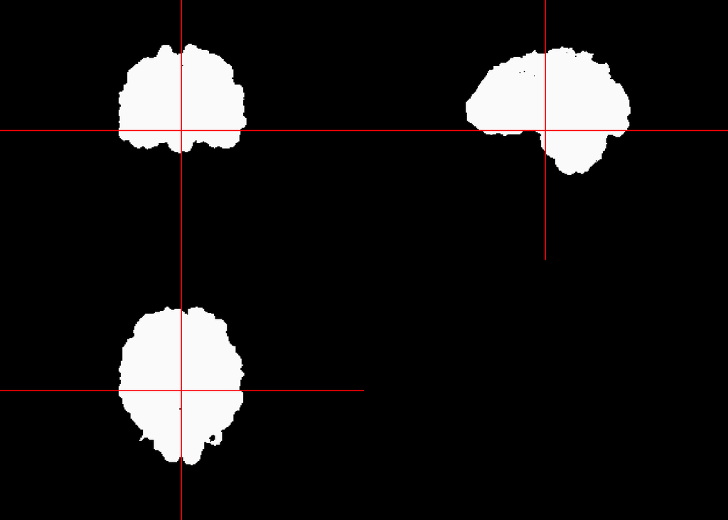

```r
# Mask
mask <- readNIfTI('113-01-MPRAGE_mask.nii.gz', reorient=FALSE)
orthographic(mask)
```

2. Create a dataframe with the intensities from all 3 sequences and the brain mask. Make sure to create a voxel level identifier for each voxel (as done in the lecture).

```r
library(ggplot2)
library(dplyr)
brain.data <- data.frame(
  T1 = c(T1),
  FLAIR = c(FLAIR),
  T2 = c(T2),
  mask = c(mask)
) %>%
  mutate(voxel.id = 1:n())
```

3. Perform k-means clustering using the intensisites from all three imaging sequences over the brain mask. Make sure to normalize the intensities before performing k-means.

```r
brain.data.mask <- brain.data %>%
  filter(mask == 1)
brain.data.cluster <- brain.data.mask %>%
  select(T1,FLAIR,T2)

# Normalize the intensity values
brain.data.cluster.norm <- scale(brain.data.cluster)

# Perform k-means clustering
kmeans.brain <- kmeans(
  x = brain.data.cluster.norm,
  centers = 3)

# Add the cluster assignments to the data frame
brain.data.mask$cluster <- kmeans.brain$cluster
brain.data <- brain.data %>%
  left_join(brain.data.mask %>% select(voxel.id,
                                       cluster))
```

4. Put the cluster assignments back into a nifti array. Plot the image of the assigned clusters using the orthographic function.

```r
library(fslr)
```

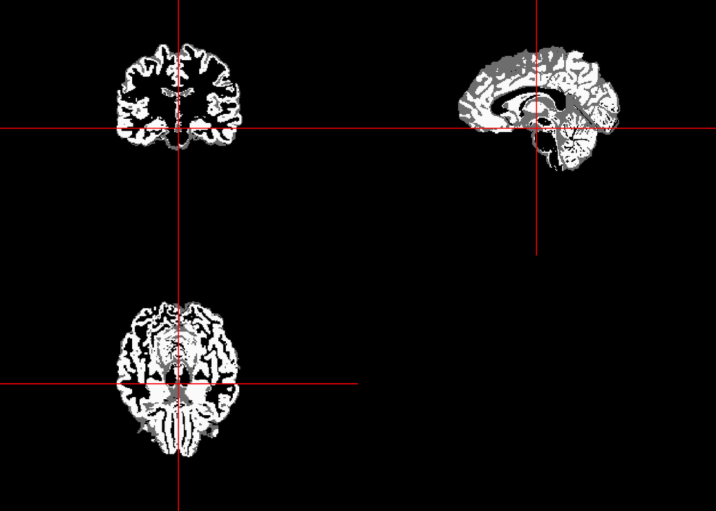

```r
clusters <- niftiarr(FLAIR, brain.data$cluster)
orthographic(clusters)
```

5. Plot each cluster individually using the orthographic function and identify what tissue class the cluster is segmenting.

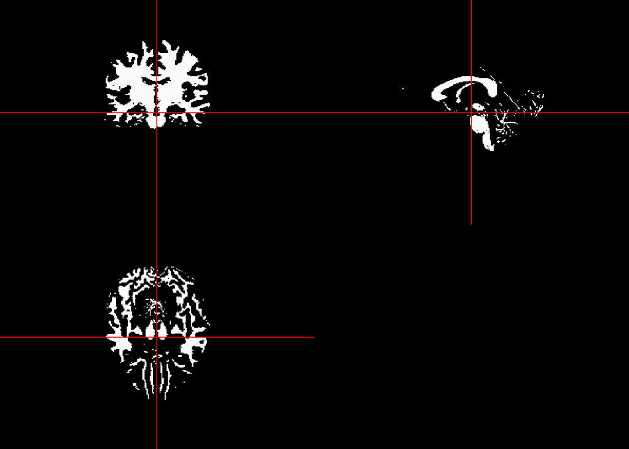

```r
orthographic(clusters == 1)
```

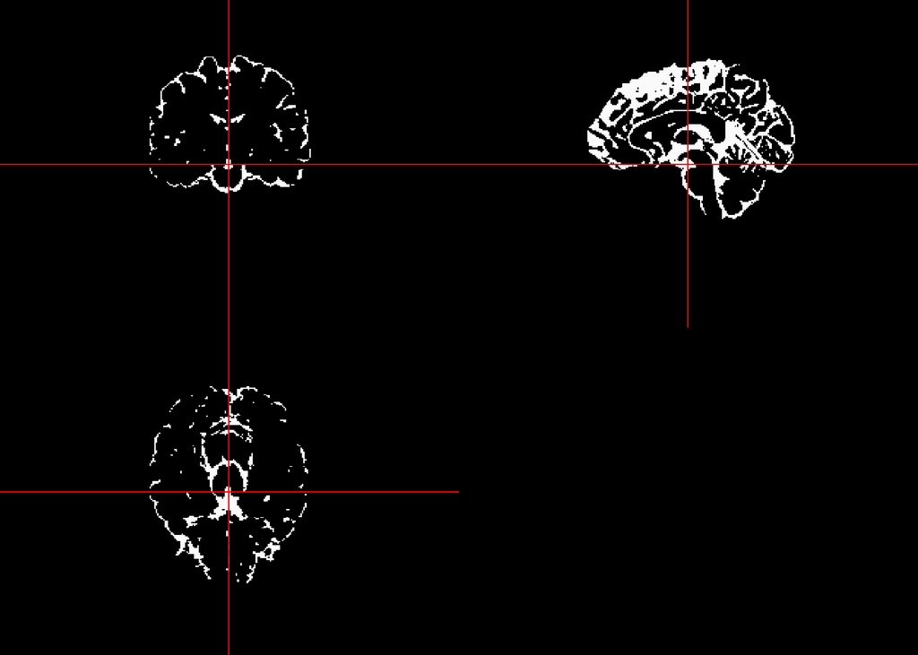

```r
orthographic(clusters == 2)
```

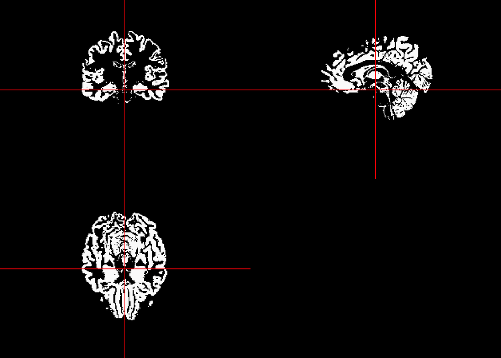

```r
orthographic(clusters == 3)
```

6. Sample 100 voxels from each of the clusters. Plot the T1 versus the FLAIR intensity for these 300 voxels in a scatter plot and color by cluster. Then the T1 versus the T2 and the T2 versus the FLAIR. Comment on what you observe.

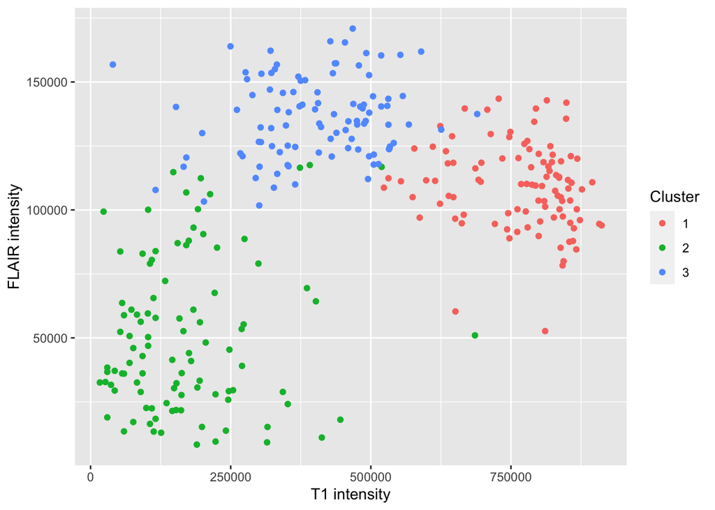

```r
# Select 100 voxels from each of the three clusters
cluster1_voxels <- brain.data %>% filter(cluster == 1) %>% sample_n(100)
cluster2_voxels <- brain.data %>% filter(cluster == 2) %>% sample_n(100)
cluster3_voxels <- brain.data %>% filter(cluster == 3) %>% sample_n(100)

# Combine the selected voxels into a single data frame
selected_voxels <- rbind(cluster1_voxels, cluster2_voxels, cluster3_voxels)

# Create scatter plots of T1 vs FLAIR, T1 vs T2, and T2 vs FLAIR
ggplot(selected_voxels, aes(x = T1, y = FLAIR, color = factor(cluster))) +
  geom_point() +
  labs(x = "T1 intensity", y = "FLAIR intensity", color = "Cluster")
```

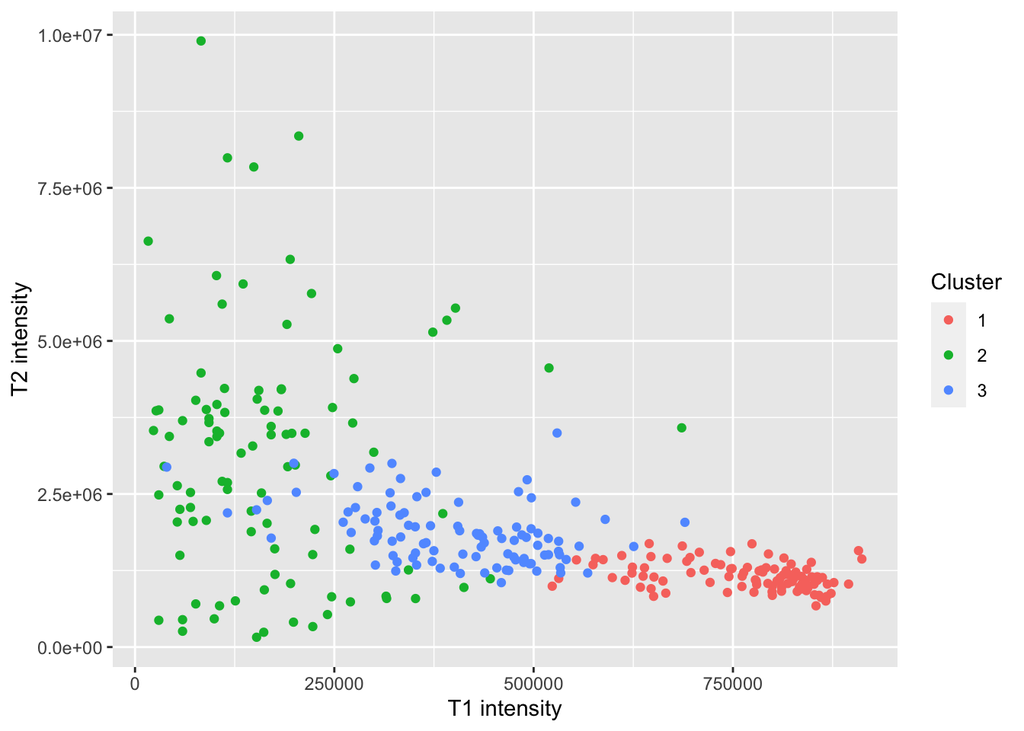

```r
ggplot(selected_voxels, aes(x = T1, y = T2, color = factor(cluster))) +
  geom_point() +
  labs(x = "T1 intensity", y = "T2 intensity", color = "Cluster")
```

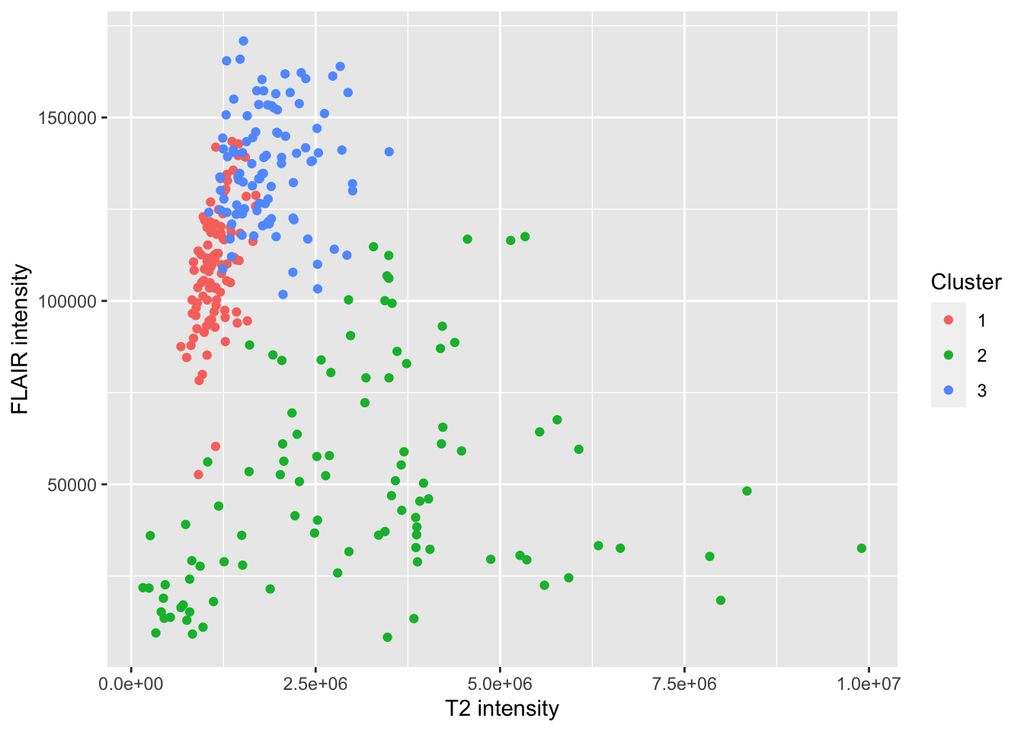

```r
ggplot(selected_voxels, aes(x = T2, y = FLAIR, color = factor(cluster))) +
  geom_point() +
  labs(x = "T2 intensity", y = "FLAIR intensity", color = "Cluster")
```